# July 2024 Bumps: Reddit Group Birth Experiences Survey

July 2024 Bumps: Reddit Group Birth Experiences Survey November 2024

## Introduction

Welcome to the results of the birth experiences survey for the reddit group “July 2024 Bumps.” This is a group of people from all over the world who were expecting little ones to join them in approximately July 2024. This is a follow-up from the original demographic survey we did earlier in 2024. Thank you for contributing to the survey!

Note that some of the data allowed free-form / unstructured responses and therefore did not lend itself well to tabular summary. In these cases, the authors have either assigned the response to the most reasonable category, or excluded it from the summary. We have summarized the data for each variable only and not stratified between multiple variables, to avoid potential identification of individuals.

There were five respondents who had twins and 450 respondents who had a single baby.

## Frequency plot for each question

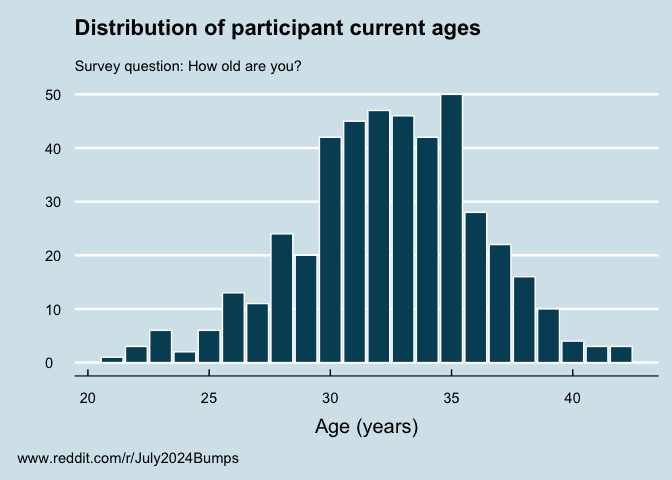

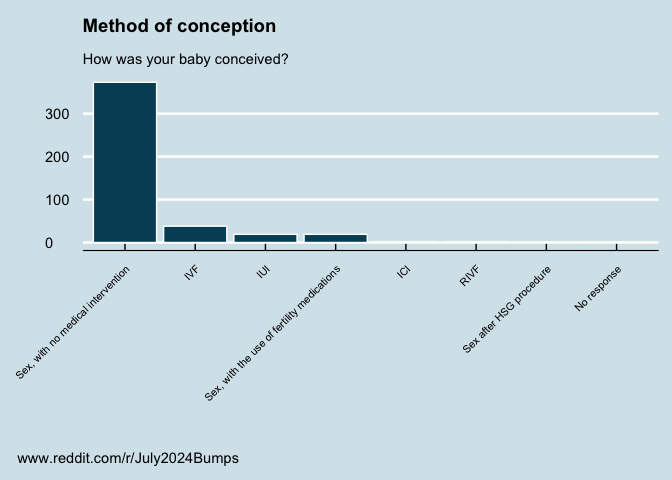

[figure not shown]

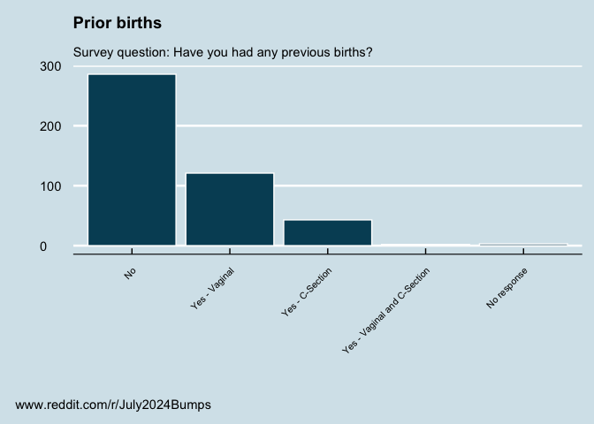

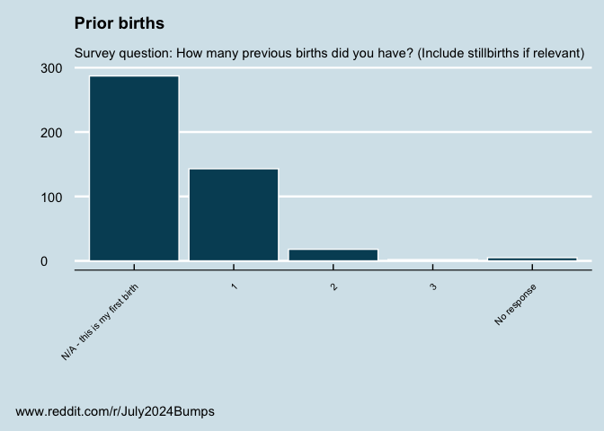

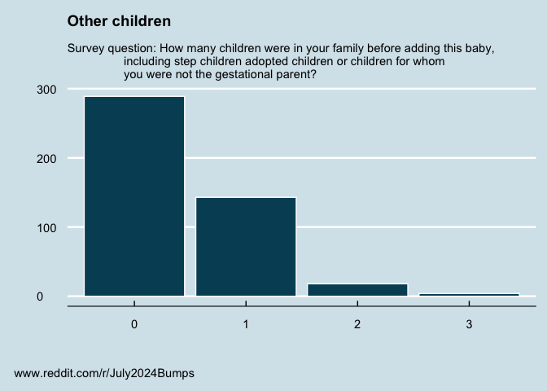

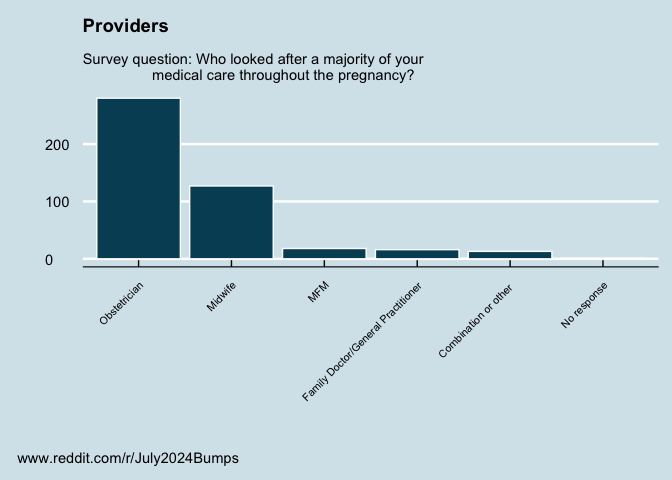

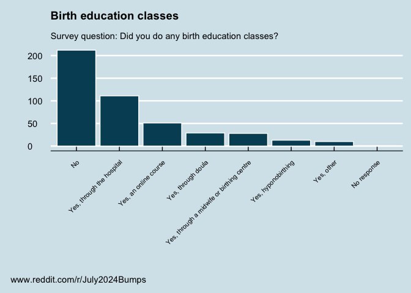

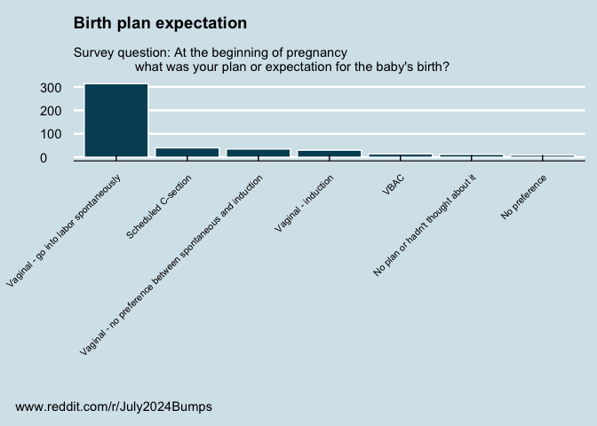

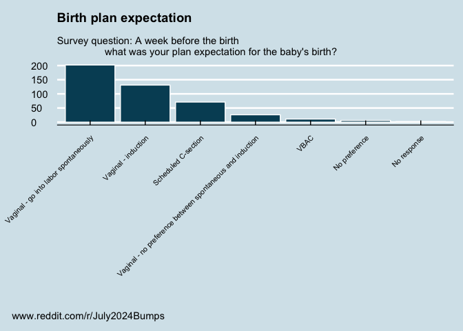

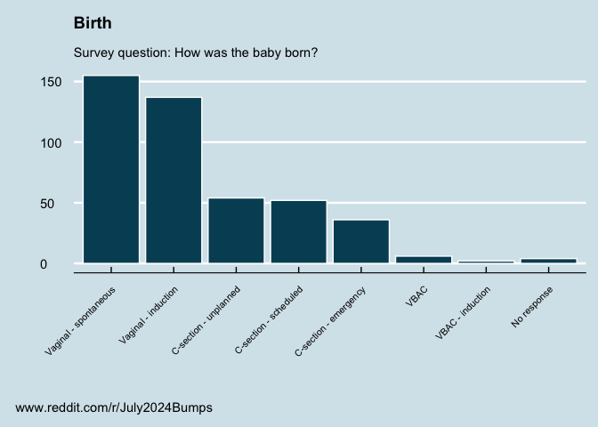

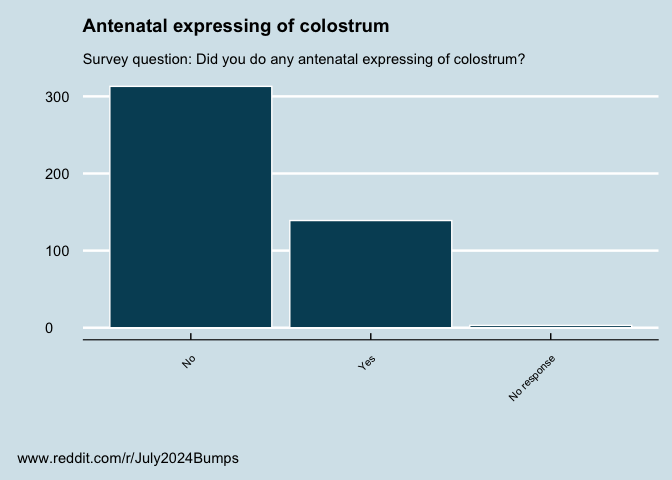

[50 more figures not shown]

## Special requests

### Most popular birthday

The most popular birthday was July 11 (29 babies born!), followed by July 13 with 17 babies born.

### List of names

|  | Name | Frequency |
| --- | --- | --- |
| 1 | Clara | 1 |
| 2 | Abigail | 1 |
| 3 | Abraham | 1 |
| 4 | Addison Louise | 1 |
| 5 | Adeline | 1 |
| 6 | Adeline Lily | 1 |
| 7 | Agnes | 1 |
| 8 | Aisling | 1 |
| 9 | Alaina | 1 |
| 10 | Alice | 1 |

[output cut: 291 more lines]

### More special requests may be coming - feel free to post additional requests!

#### Thank you

*For more information on the data or analyses, please contact the moderators of /r/July2024Bumps. The cleaned, de-identified dataset is available in .xlsx or .csv formats, or others (SPSS, SAS, etc) upon request, for members of this subreddit only, upon approval of the moderators and group. All analyses were done in R and scripts can be shared upon request.*